# Bayesian Longitudinal Multilevel Models

Using brms / STAN

Andy Grogan-Kaylor https://www.umich.edu/~agrogan (University of Michigan)https://www.umich.edu  
2022-10-06

# Set Up 🌲

You will need to install the relevant packages: `lme4` for frequentist MLM, and `brms`, which also installs `STAN`, for Bayesian MLM.

```r
install.packages(c("lme4", "brms"))
```

# Gutten Tree Data 🌲

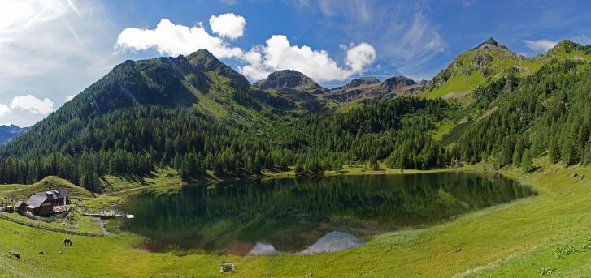

Norway Spruce and Larch Forest in Austrian Alps, https://ec.europa.eu/jrc/en/research-topic/forestry/qr-tree-project/norway-spruce

The data used in this example are derived from the R package *Functions and Datasets for “Forest Analytics with R”*.

According to the documentation, the source of these data are: “von Guttenberg’s Norway spruce (Picea abies [L.] Karst) tree measurement data.”

The documentation goes on to further note that:

> “The data are measures from 107 trees. The trees were selected as being of average size from healthy and well stocked stands in the Alps.”

# Import The Data 🌲

```r
library(haven)

gutten <- read_dta("gutten.dta")

gutten
```

```
# A tibble: 1,200 × 9
      site location  tree age_base height dbh_cm volume age_bh tree_ID
   <dbl+l> <dbl+lb> <dbl>    <dbl>  <dbl>  <dbl>  <dbl>  <dbl> <dbl+l>
 1   1 [1]    1 [1]     1       20    4.2    4.6      5   9.67 1 [1.1]
 2   1 [1]    1 [1]     1       30    9.3   10.2     38  19.7  1 [1.1]
 3   1 [1]    1 [1]     1       40   14.9   14.9    123  29.7  1 [1.1]
 4   1 [1]    1 [1]     1       50   19.7   18.3    263  39.7  1 [1.1]
 5   1 [1]    1 [1]     1       60   23     20.7    400  49.7  1 [1.1]
 6   1 [1]    1 [1]     1       70   25.8   22.6    555  59.7  1 [1.1]
 7   1 [1]    1 [1]     1       80   27.4   24.1    688  69.7  1 [1.1]
 8   1 [1]    1 [1]     1       90   28.8   25.5    820  79.7  1 [1.1]
 9   1 [1]    1 [1]     1      100   30     26.5    928  89.7  1 [1.1]
10   1 [1]    1 [1]     1      110   30.9   27.3   1023  99.7  1 [1.1]
# … with 1,190 more rows
```

# Variables 🌲

`site` Growth *quality* class of the tree’s habitat. 5 levels.

`location` Distinguishes tree *location*. 7 levels.

`tree` An identifier for the tree within location.

`age.base` The tree age taken at ground level.

`height` Tree height, m.

`dbh.cm` Tree diameter, cm.

`volume` Tree volume.

`age.bh` Tree age taken at 1.3 m.

`tree.ID` A factor uniquely identifying the tree.

# A Basic Multilevel Model 🌲

# Graph (Spaghetti Plot)

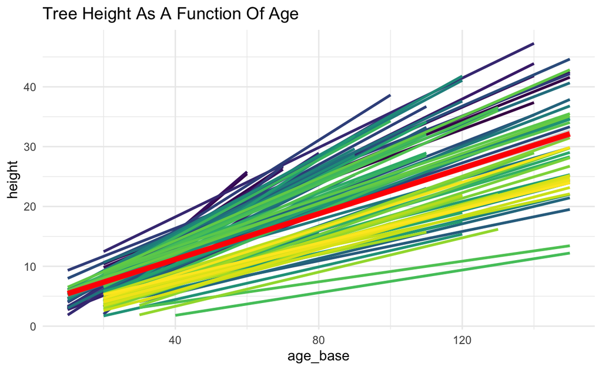

```r
library(ggplot2)

ggplot(gutten,
       aes(x = age_base, # x is tree age
           y = height)) + # y is tree height
  geom_smooth(aes(color = as.factor(tree_ID)),
              method = "lm",
              se = FALSE) + # linear model for each tree
  geom_smooth(method = "lm",
              color = "red",
              size = 2) + # linear model
  labs(title = "Tree Height As A Function Of Age") +
  scale_color_viridis_d() + # nice graph colors for trees
  theme_minimal() +
  theme(legend.position = "none")
```

# Frequentist Model in `lmer` 🌲

> NB: `*` provides with an interaction term and main effects.

```r
library(lme4)

fit1 <- lmer(height ~ age_base * site + (1 | tree_ID),
             data = gutten)

summary(fit1)
```

```
Linear mixed model fit by REML ['lmerMod']
Formula: height ~ age_base * site + (1 | tree_ID)
   Data: gutten

REML criterion at convergence: 5565.2

Scaled residuals:
    Min      1Q  Median      3Q     Max
-3.7145 -0.5346  0.1588  0.6739  2.5713

Random effects:
 Groups   Name        Variance Std.Dev.
 tree_ID  (Intercept) 2.462    1.569
 Residual             5.037    2.244
Number of obs: 1200, groups:  tree_ID, 107

Fixed effects:
               Estimate Std. Error t value
(Intercept)    4.736446   0.497759   9.516
age_base       0.324732   0.004449  72.990
site          -1.013740   0.175037  -5.792
age_base:site -0.040400   0.001488 -27.154

Correlation of Fixed Effects:
            (Intr) age_bs site
age_base    -0.610
site        -0.906  0.546
age_base:st  0.574 -0.910 -0.625
```

# Bayesian Model With `brms` (Less Informative Default Priors) 🌲

> The models below take a non-trivial amount of time to run.

```r
library(brms)

fit2 <- brm(height ~ age_base * site + (1 | tree_ID),
            data = gutten,
            family = gaussian(),
            warmup = 2000,
            iter = 5000)
summary(fit2)
```

```
 Family: gaussian
  Links: mu = identity; sigma = identity
Formula: height ~ age_base * site + (1 | tree_ID)
   Data: gutten (Number of observations: 1200)
  Draws: 4 chains, each with iter = 5000; warmup = 2000; thin = 1;
         total post-warmup draws = 12000

Group-Level Effects:
~tree_ID (Number of levels: 107)
              Estimate Est.Error l-95% CI u-95% CI Rhat Bulk_ESS
sd(Intercept)     1.59      0.13     1.35     1.85 1.00     4012
              Tail_ESS
sd(Intercept)     6890

Population-Level Effects:
              Estimate Est.Error l-95% CI u-95% CI Rhat Bulk_ESS
Intercept         4.74      0.50     3.77     5.73 1.00     4695
age_base          0.32      0.00     0.32     0.33 1.00    17134
site             -1.01      0.18    -1.36    -0.67 1.00     4710
age_base:site    -0.04      0.00    -0.04    -0.04 1.00    17388
              Tail_ESS
Intercept         7001
age_base          9915
site              5964
age_base:site     9255

Family Specific Parameters:
      Estimate Est.Error l-95% CI u-95% CI Rhat Bulk_ESS Tail_ESS
sigma     2.25      0.05     2.15     2.34 1.00    21717     9392

Draws were sampled using sampling(NUTS). For each parameter, Bulk_ESS
and Tail_ESS are effective sample size measures, and Rhat is the potential
scale reduction factor on split chains (at convergence, Rhat = 1).
```

# Set Informative Priors 🌲

```r
prior1 <- c(
  prior(normal(0, 10), class = Intercept),
  prior(normal(0, 10), class = b, coef = site) #,
  # prior(cauchy(0, 10), class = sigma)
)
```

# Run The Model With More Informative Prior 🌲

```r
fit3 <- brm(height ~ age_base * site + (1 | tree_ID),
            data = gutten,
            family = gaussian(),
            prior = prior1,
            warmup = 2000,
            iter = 5000)
summary(fit3)
```

```
 Family: gaussian
  Links: mu = identity; sigma = identity
Formula: height ~ age_base * site + (1 | tree_ID)
   Data: gutten (Number of observations: 1200)
  Draws: 4 chains, each with iter = 5000; warmup = 2000; thin = 1;
         total post-warmup draws = 12000

Group-Level Effects:
~tree_ID (Number of levels: 107)
              Estimate Est.Error l-95% CI u-95% CI Rhat Bulk_ESS
sd(Intercept)     1.59      0.13     1.35     1.87 1.00     3989
              Tail_ESS
sd(Intercept)     7092

Population-Level Effects:
              Estimate Est.Error l-95% CI u-95% CI Rhat Bulk_ESS
Intercept         4.72      0.50     3.73     5.70 1.00     4864
age_base          0.32      0.00     0.32     0.33 1.00    15193
site             -1.01      0.18    -1.36    -0.66 1.00     4679
age_base:site    -0.04      0.00    -0.04    -0.04 1.00    15305
              Tail_ESS
Intercept         7287
age_base          9877
site              6572
age_base:site     9415

Family Specific Parameters:
      Estimate Est.Error l-95% CI u-95% CI Rhat Bulk_ESS Tail_ESS
sigma     2.25      0.05     2.15     2.34 1.00    20932     8889

Draws were sampled using sampling(NUTS). For each parameter, Bulk_ESS
and Tail_ESS are effective sample size measures, and Rhat is the potential
scale reduction factor on split chains (at convergence, Rhat = 1).
```

# Plot Posterior Distributions and Trace Plots 🌲

> `plot(fit3)` will give me a reasonable plot of *every* parameter, but the layout may not be optimal. I am using separate plot calls below, but to do so, I need to know the *names* of the parameters, which can be tricky in `brms`. One way to do this is to use `plot(fit3)` to see all the parameter names, and then divide the single `plot` call into multiple `plot` calls to improve the layout.

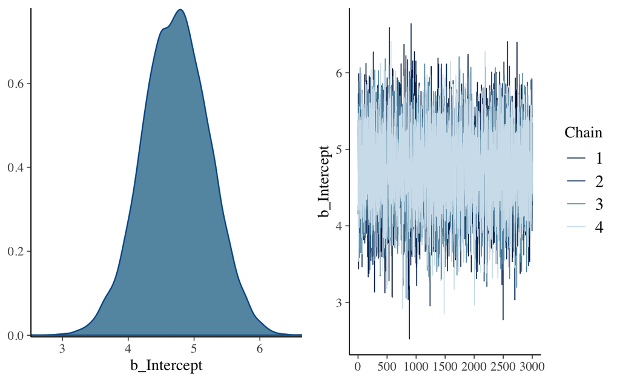

```r
# plot(fit3)

plot(fit3, variable = c("b_Intercept"))
```

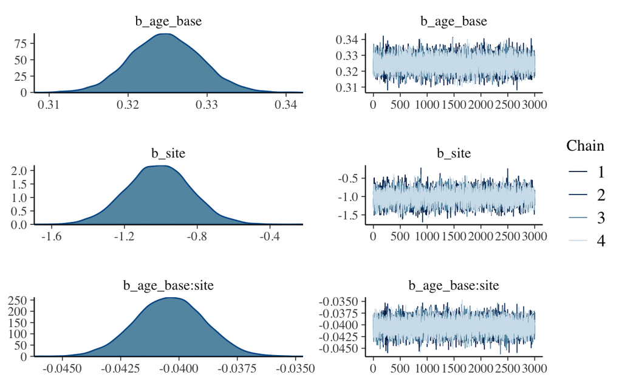

```r
plot(fit3,
     variable = c("b_age_base",
                  "b_site",
                  "b_age_base:site")) # regression slopes
```

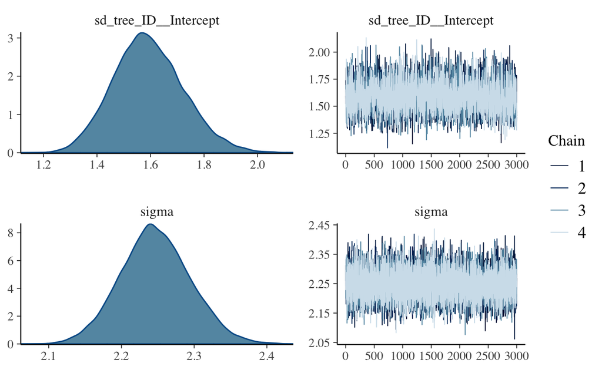

```r
plot(fit3, variable = c("sd_tree_ID__Intercept",
                        "sigma")) # variance parameters
```

# Compare All 3 Models 🌲

```r
tab_model(fit1, fit2, fit3,
          dv.labels = c("lmer", "brms default priors", "brms informative priors"),
          show.se = TRUE,
          show.ci = 0.95,
          show.stat = TRUE)
```

|  | lmer |  |  |  |  | brms default priors |  |  | brms informative priors |  |  |
| --- | --- | --- | --- | --- | --- | --- | --- | --- | --- | --- | --- |
| Predictors | Estimates | std. Error | CI | Statistic | p | Estimates | std. Error | CI (95%) | Estimates | std. Error | CI (95%) |
| (Intercept) | 4.74 | 0.50 | 3.76 – 5.71 | 9.52 | **<0.001** |  |  |  |  |  |  |
| age.base | 0.32 | 0.00 | 0.32 – 0.33 | 72.99 | **<0.001** | 0.32 | 0.00 | 0.32 – 0.33 | 0.32 | 0.00 | 0.32 – 0.33 |
| site | -1.01 | 0.18 | -1.36 – -0.67 | -5.79 | **<0.001** | -1.01 | 0.17 | -1.36 – -0.67 | -1.01 | 0.18 | -1.36 – -0.66 |
| age_base:site | -0.04 | 0.00 | -0.04 – -0.04 | -27.15 | **<0.001** | -0.04 | 0.00 | -0.04 – -0.04 | -0.04 | 0.00 | -0.04 – -0.04 |
| Intercept |  |  |  |  |  | 4.73 | 0.49 | 3.77 – 5.73 | 4.73 | 0.51 | 3.73 – 5.70 |
| Random Effects |  |  |  |  |  |  |  |  |  |  |  |
| σ<sup>2</sup> | 5.04 |  |  |  |  | 5.05 |  |  | 5.05 |  |  |
| τ<sub>00</sub> | 2.46 <sub>tree_ID</sub> |  |  |  |  | 2.51 <sub>tree_ID</sub> |  |  | 2.54 <sub>tree_ID</sub> |  |  |
| ICC | 0.33 |  |  |  |  | 0.33 |  |  | 0.33 |  |  |
| N | 107 <sub>tree_ID</sub> |  |  |  |  | 107 <sub>tree_ID</sub> |  |  | 107 <sub>tree_ID</sub> |  |  |
| Observations | 1200 |  |  |  |  | 1200 |  |  | 1200 |  |  |
| Marginal R<sup>2</sup> / Conditional R<sup>2</sup> | 0.916 / 0.944 |  |  |  |  | 0.915 / 0.941 |  |  | 0.915 / 0.941 |  |  |